# Breast Cancer Image Diagnosis Classification by SVM

Yuan Du

12/5/2019

# Introduction

⚠️Breast cancer is the second leading cause of cancer death in women after lung cancer.

⚠️There is a 1 in 8 chance she will develop breast cancer in the United States.

⚠️The average 5-year survival rate for women with invasive breast cancer is 90%.

🔴If the cancer is located only in the breast, the 5-year survival rate of women with breast cancer is 99%. 62% of people with breast cancer are diagnosed with this stage.

🔴If the cancer has spread to the regional lymph nodes, the 5-year survival rate is 85%.

🔴If the cancer has spread to a distant part of the body, the 5-year survival rate is 27%.

## Dataset description:

Breast Cancer Wisconsin (Diagnostic) Data Set by University of Wisconsin, Clinical Sciences Center was used. There are 569 number of instances, and 32 attributes.First two columns are ID number and Diagnosis (M = malignant, B = benign). Ten real-valued features are computed for each cell nucleus: a) radius (mean of distances from center to points on the perimeter) b) texture (standard deviation of gray-scale values) c) perimeter d) area e) smoothness (local variation in radius lengths) f) compactness (perimeter^2 / area - 1.0) g) concavity (severity of concave portions of the contour) h) concave points (number of concave portions of the contour) i) symmetry j) fractal dimension (“coastline approximation” - 1)

The mean, standard error and “worst” or largest (mean of the three largest values) of these features were computed for each image, resulting in 30 features. For instance, field 3 is Mean Radius, field 13 is Radius SE, field 23 is Worst Radius.

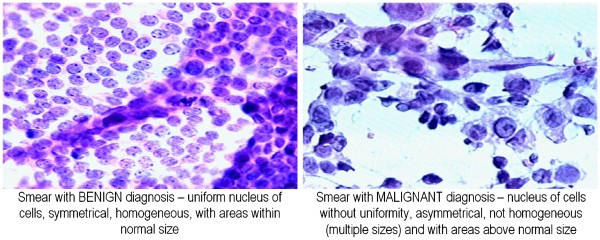

Figure 1: Breast cancer cell

```r
knitr::include_graphics('Cell.jpg')
```

## Data Problems:

High dimensions: There are there are 32 attributes for 569 number of instances, which is considered high dimensions for these instances.Another major problem is multicolinearity. The same feature for each image was computed in three ways - mean, standard error and “worst” or largest (mean of the three largest values), results in 30 variables.

# Methodology

SVM with radial basis function (RBF) kernel was used to analyze the data, since it’s a classification problem and SVM is a good method for data with high dimensions. SVM Estimator
$$S_n: (\mathcal{X} \, X \, \mathcal{Y})^n \to H, \quad D_n \mapsto f_{L,D_n,\lambda_{D_n}}$$

, where $f_{L,D_n,\lambda_{D_n}}$ is that function $f \in H$ which minimizes
$$\frac{1}{n} \sum L(x_i,y_i,f(x_i)) + \lambda_{D_n}||f||_H^2$$
.

## Investiagte the Asymptotic properties on estimators:

Assumptions to prove that Empirical SVM $f_{L,D_n,\lambda_{D_n}}$ is converged to theoretical SVM $f_{L,P,\lambda_0}$. This is
$$\sqrt{n}(f_{L,D_n,\lambda_{D_n}} - f_{L,P,\lambda_0})$$
converges weakly to a (zero-mean) Gaussian process in the function space H.:

1. $\mathcal{X}$ bounded and closed, $\mathcal{Y} \in \{-1,1\}$ in Function space H, $f:\mathcal{X} \to \mathbb{R}$, $(X_1,Y_1),\dots,(X_n,Y_n)$ are independent and identically distributed according to some unknown probability measure P on $(\mathcal{X} X \mathcal{Y},\mathcal{B}(\mathcal{X} X \mathcal{Y}))$.
2. Assume Loss function is two times continuously differentiable in the third argument. This assumption is not based on any unknown entity as such model distribution P.
3. Assume L is a P-integrable Nemitski loss function.
4. $\lambda$ is random sequence, so it’s possible to use any data-driven method for choosing the regulization parameter, such as cross-validation. It’s desirable to have a bound
   $$0 \leq \mathcal{R}_{L,P}(f_{L,P,\lambda_0}) - \mathcal{R}_{L,P}^* \leq C(\lambda_0) \to 0 \text{for} \lambda \to 0$$
   to find $\lambda$.

Asymptotic properties of support vector machines are investigated. It is shown that the difference between the empirical and the theoretical SVM is asymptotically normal with rate $\sqrt{n}$; that is, $\sqrt{n}(f_{L,D_n,\lambda_{D_n}} - f_{L,P,\lambda_0})$ converges to a Gaussian process in the function space H.

These results are not only of theoretical interest but also be a starting point for statistical inferences such as confidence intervals and hypothesis testing.

Without any of such assumptions,similar results are not possible as follows from the no-free-lunch theorem.

# Results

There are no missing value in the dataset. Descriptive Statistics on numeric variables and target variable are non normal. Target variable diagnosis was plot in Figure 2. All attributes histograms were plotted in Figure 3 and Figure 4 by diagnosis. The figures show that there are differences between B and M Diagnosis such as area, compactness, perimeter, radius, etc.

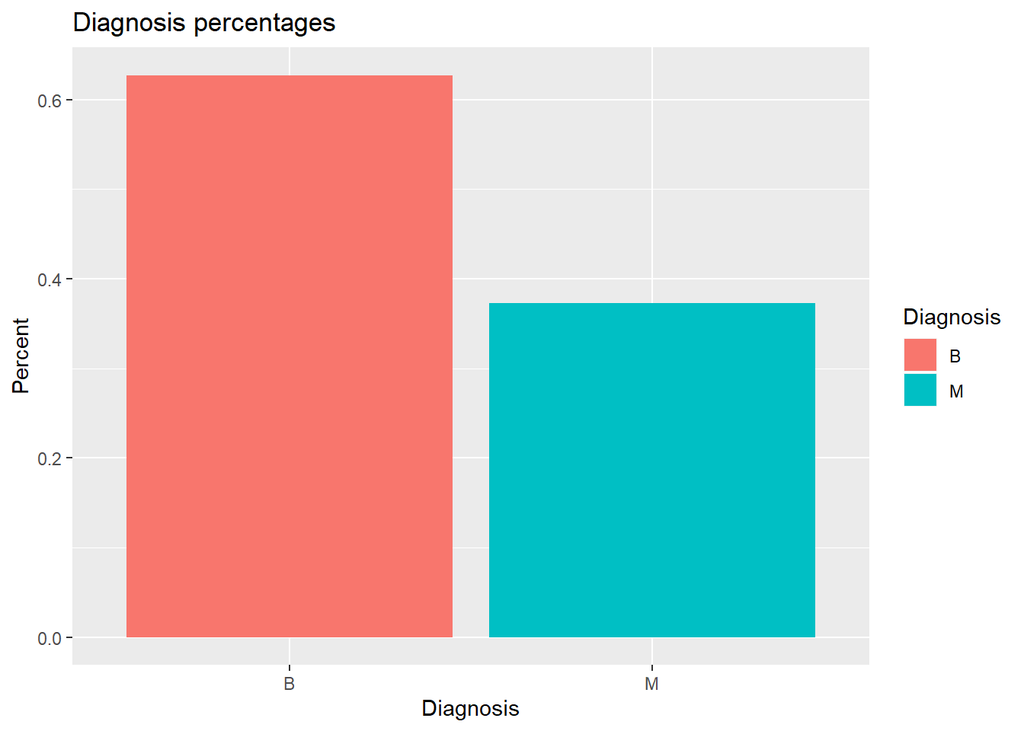

Figure 2:Diagnosis percentages

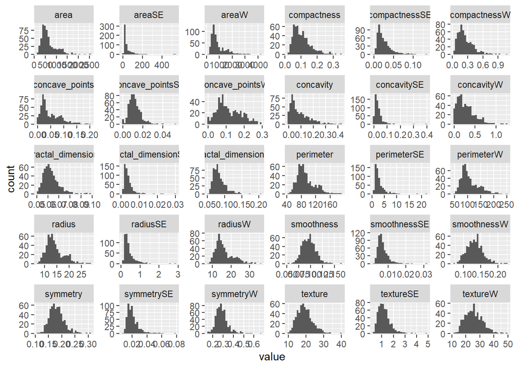

Figure 3: Baseline variable histogram

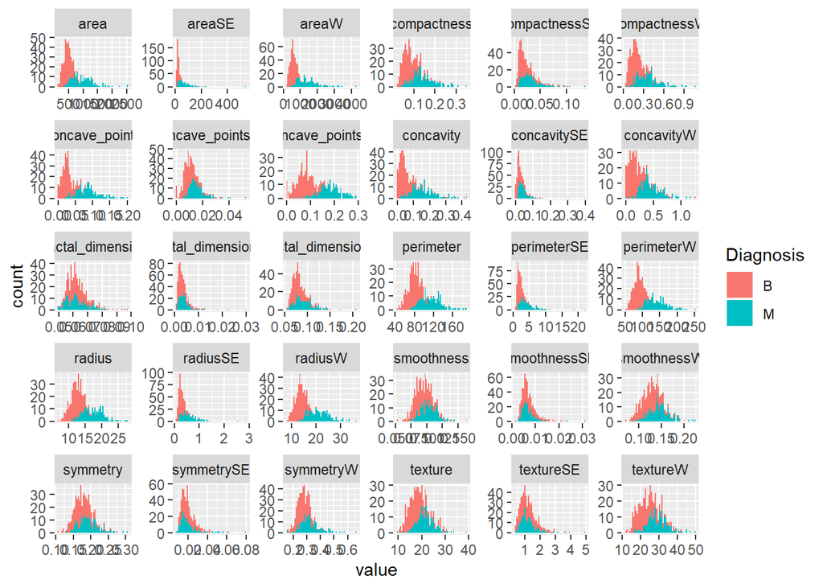

Figure 4: Baseline variable by Diagnosis histogram

Correlaion analysis was done by spearman test, since most variables are non normal distributed. Dark colors are highly correlated (Figure 5).

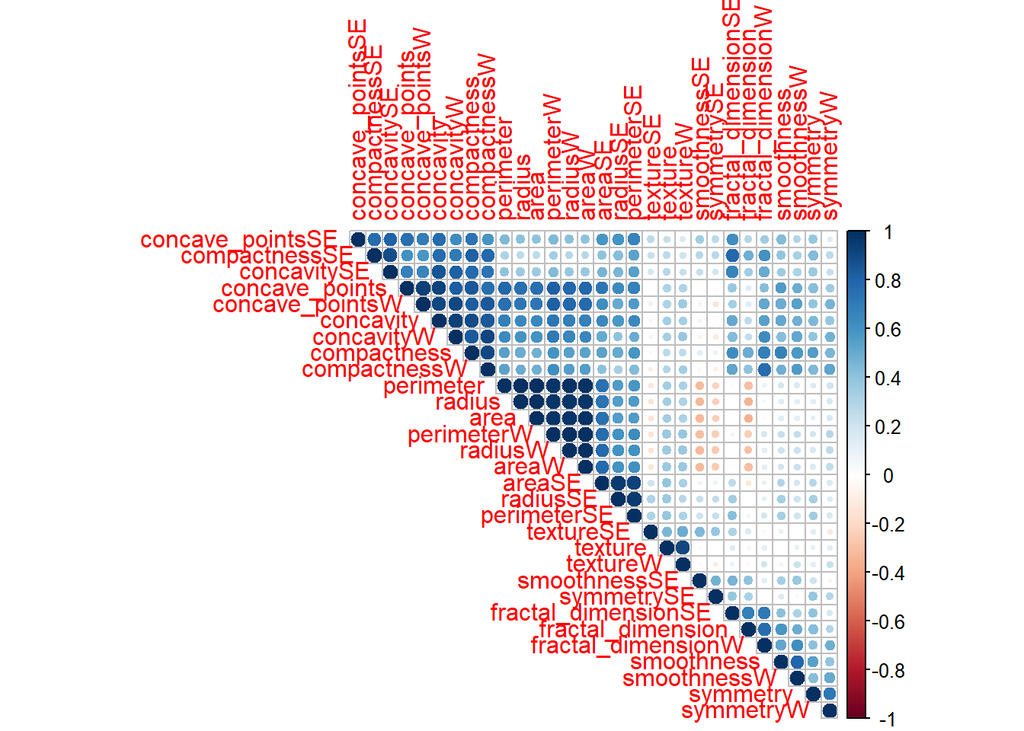

Figure 5: Correlation heatmap

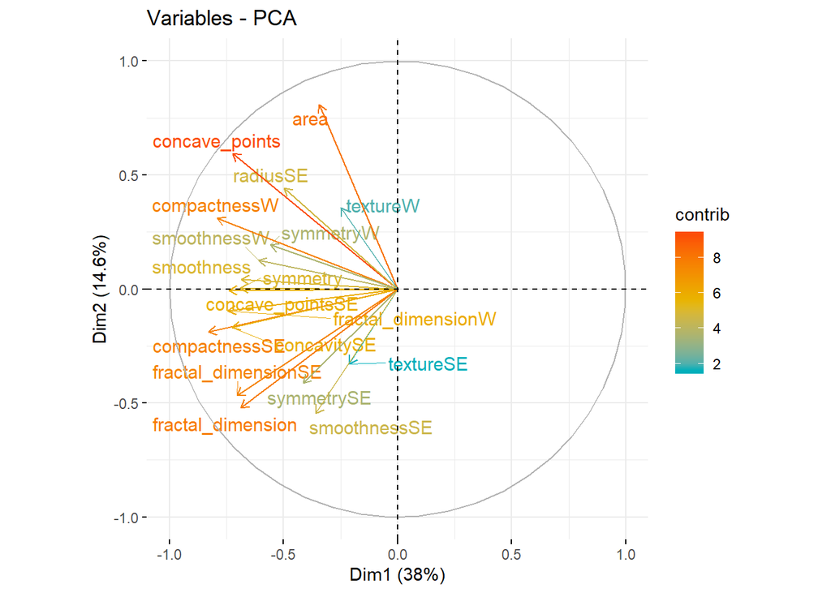